# Time Series Project

Akarsh Sahu

August 23, 2019

### Load Datset

```r
set.seed(123123)
dataPath <- "C:\\Users\\akars\\OneDrive\\Desktop\\MScA Spring\\Time Series Analysis\\Project"
data = read.csv("C:\\Users\\akars\\OneDrive\\Desktop\\MScA Spring\\Time Series Analysis\\Project\\Metro_MedianListingPricePerSqft_TopTier.csv",header = TRUE)
data.emp = read.csv("C:\\Users\\akars\\OneDrive\\Desktop\\MScA Spring\\Time Series Analysis\\Project\\EmploymentNumbers.csv",header = TRUE)
```

### Select Cities

```r
metros = c('New York, NY',
           'San Francisco, CA',
           'Chicago, IL',
           'Los Angeles-Long Beach-Anaheim, CA',
           'Miami-Fort Lauderdale, FL')

data_1 <- data[data$RegionName %in% metros,]
data_1 <- data_1[,-2]
```

### Transform Datasets & Split into Train & Test set

```r
# Transform price data
data_2 <- as.data.frame(t(data_1)[-1,])
colnames(data_2) <- t(data_1)[1,]
data_2 <- apply(data_2, c(1,2), function(x) as.numeric(x))
ts_1 <- ts(data_2, start = c(2010,1), frequency = 12)

ts_1_train = window(ts_1,start =c(2010,1),end = c(2018,7), frequency=12)
ts_1_test = window(ts_1,start =c(2018,8), frequency=12)

# Transform Employment Growth Data

ts_emp <- ts(data.emp, start = c(2010,1), frequency = 12)
ts_emp <- ts_emp[,-1]
ts_emp_train = window(ts_emp,start =c(2010,1),end = c(2018,7), frequency=12)
ts_emp_test = window(ts_emp,start =c(2018,8), frequency=12)
```

### Plot Timeseries for price per sqft and employment (in `000s)

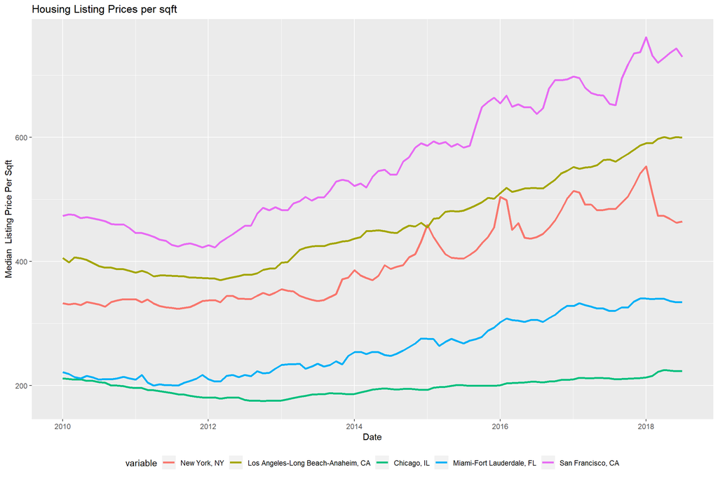

```r
plot_data <- cbind(as.data.frame(ts_1_train), Date = seq(ISOdate(2010,01,01), by = "month", length.out = 103))
plot_data_1 <- melt(plot_data, id = "Date")
ggplot(plot_data_1,aes(x=Date,y=value,colour=variable)) + geom_line(size = 1.2) + theme(legend.position="bottom") + ylab("Median  Listing Price Per Sqft") + ggtitle("Housing Listing Prices per sqft")
```

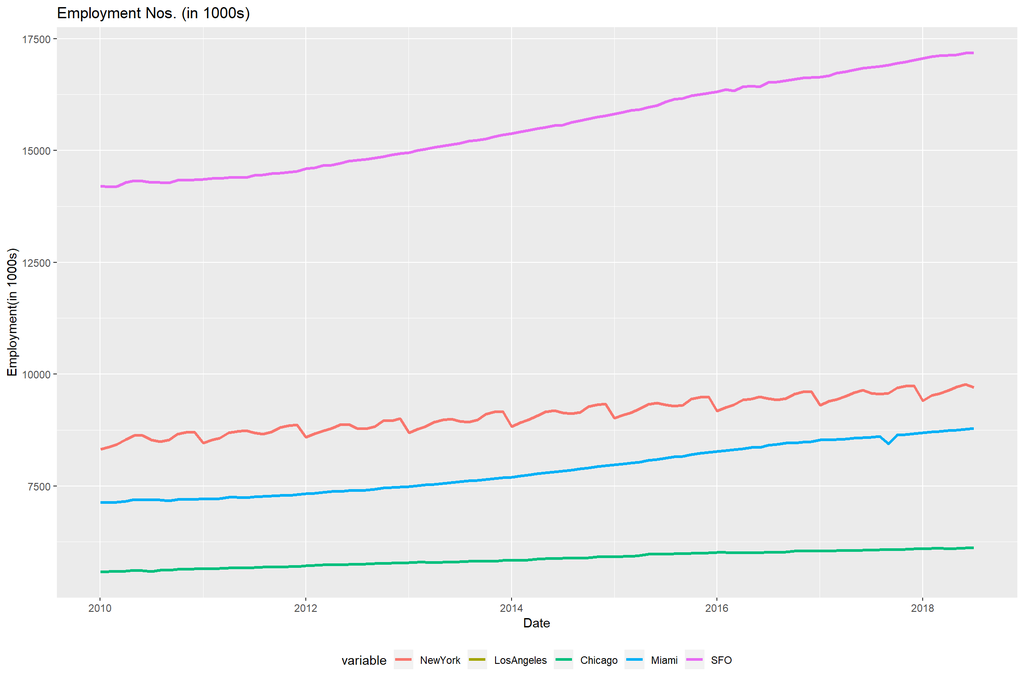

```r
plot_emp_data <- cbind(as.data.frame(ts_emp_train), Date = seq(ISOdate(2010,01,01), by = "month", length.out = 103))
plot_emp_data_1 <- melt(plot_emp_data, id = "Date")
ggplot(plot_emp_data_1,aes(x=Date,y=value,colour=variable)) + geom_line(size = 1.2) + theme(legend.position="bottom") + ylab("Employment(in 1000s)") + ggtitle("Employment Nos. (in 1000s)")
```

### Decomposing the time series plots

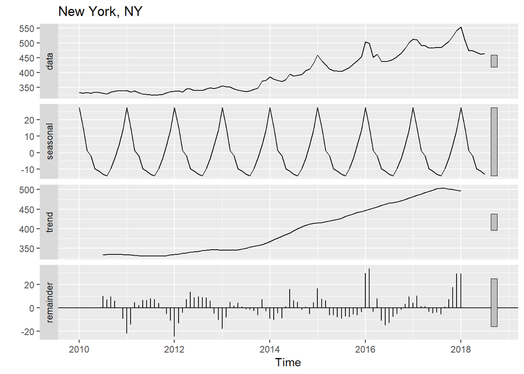

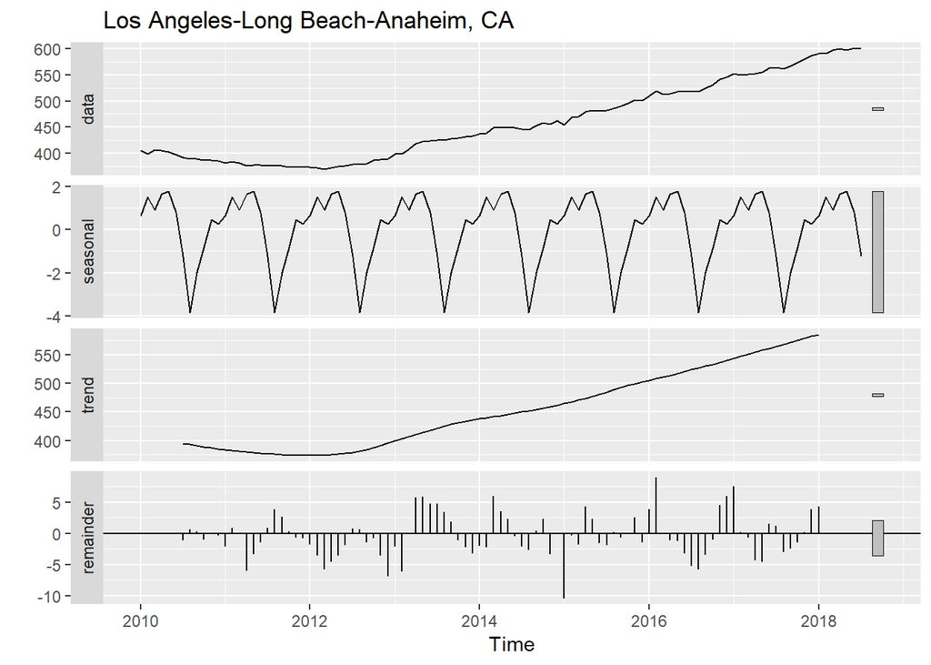

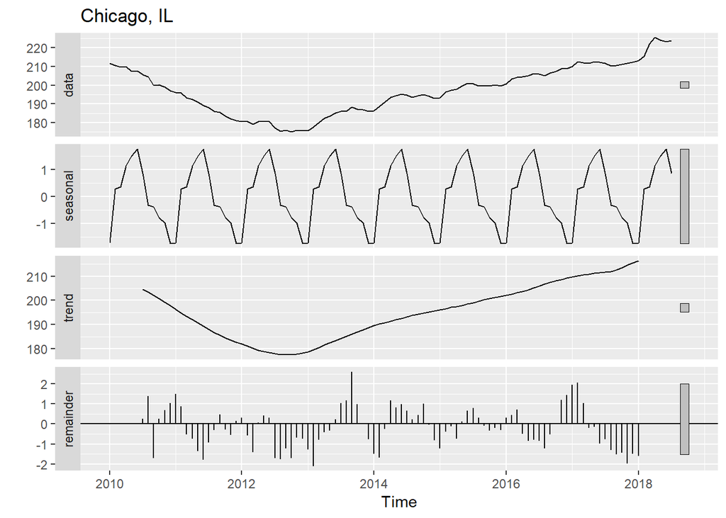

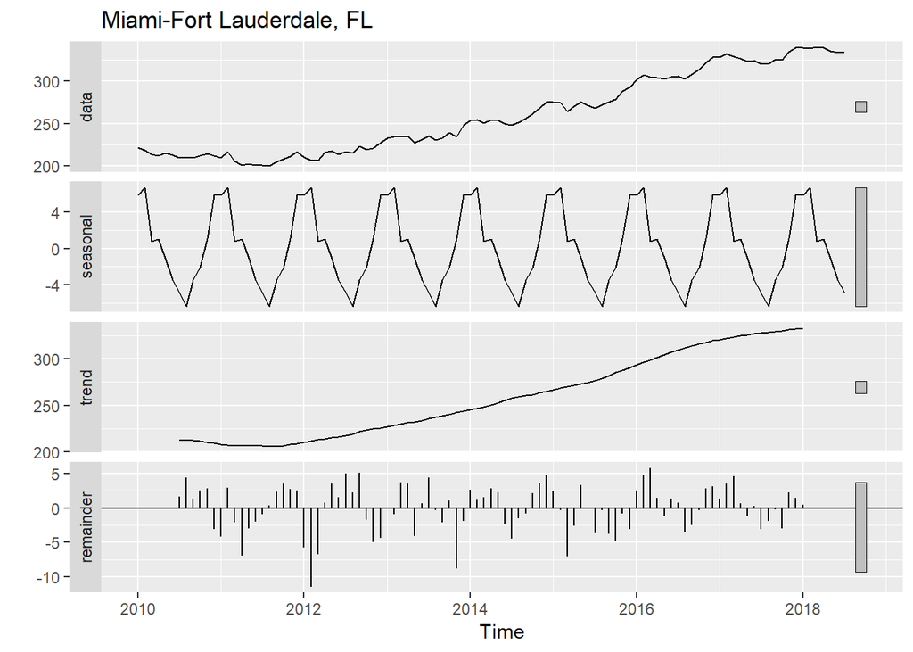

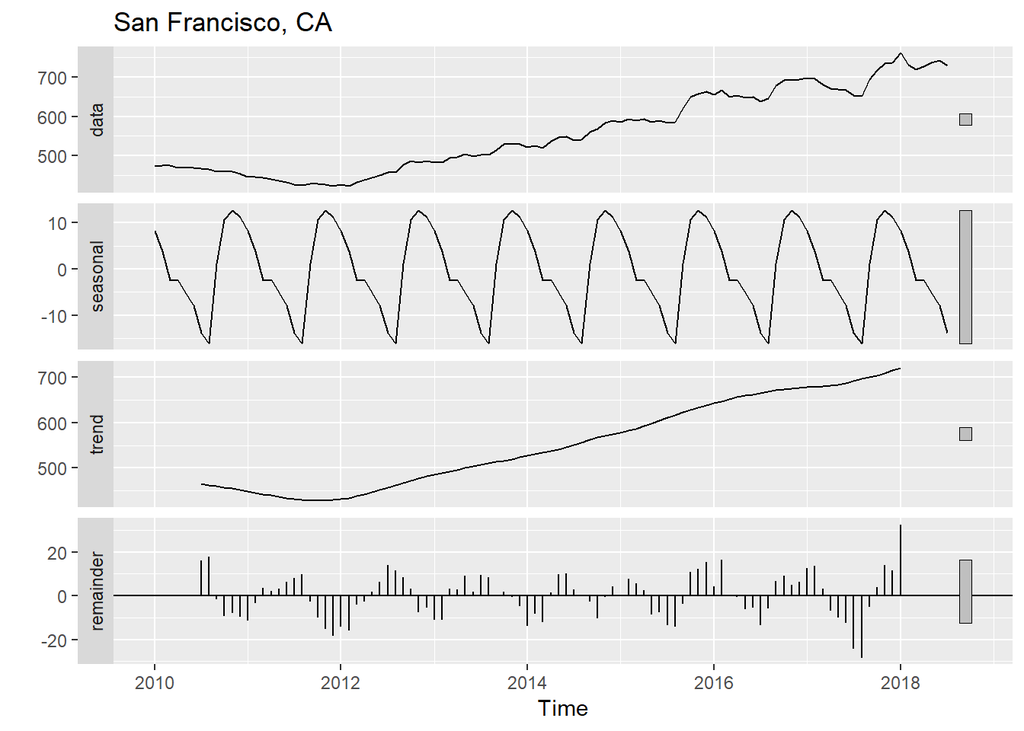

```r
for (i in 1:5){

  print(autoplot(decompose(ts_1_train[,i]), main = colnames(ts_1_train)[i]))
}
```

### ACF Plots

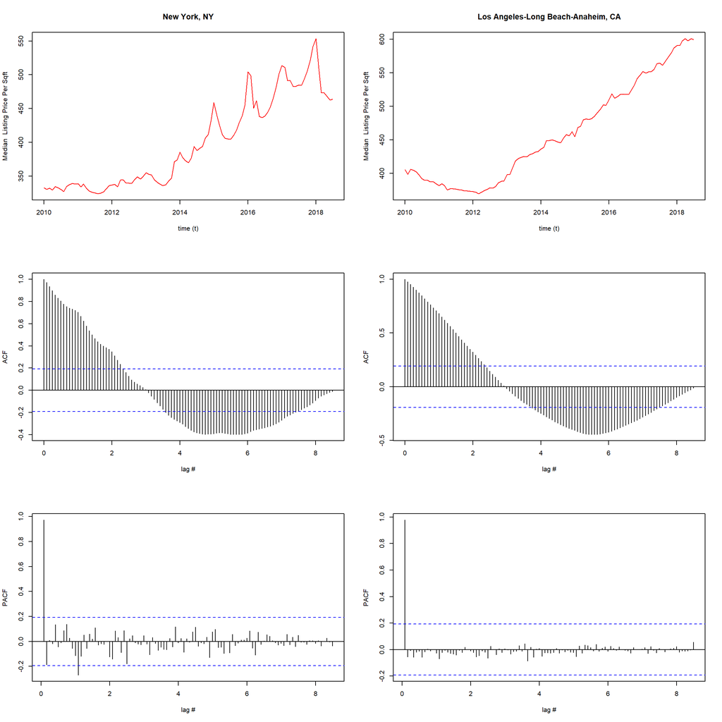

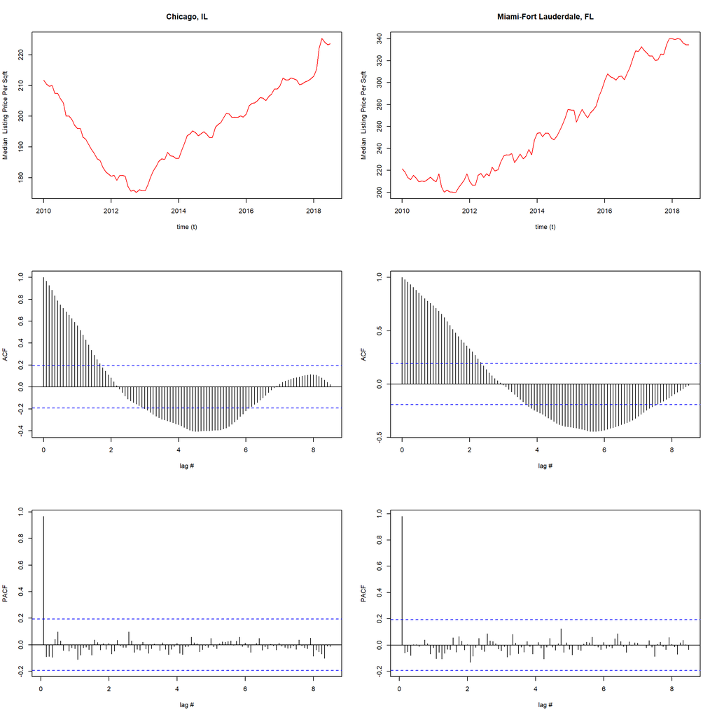

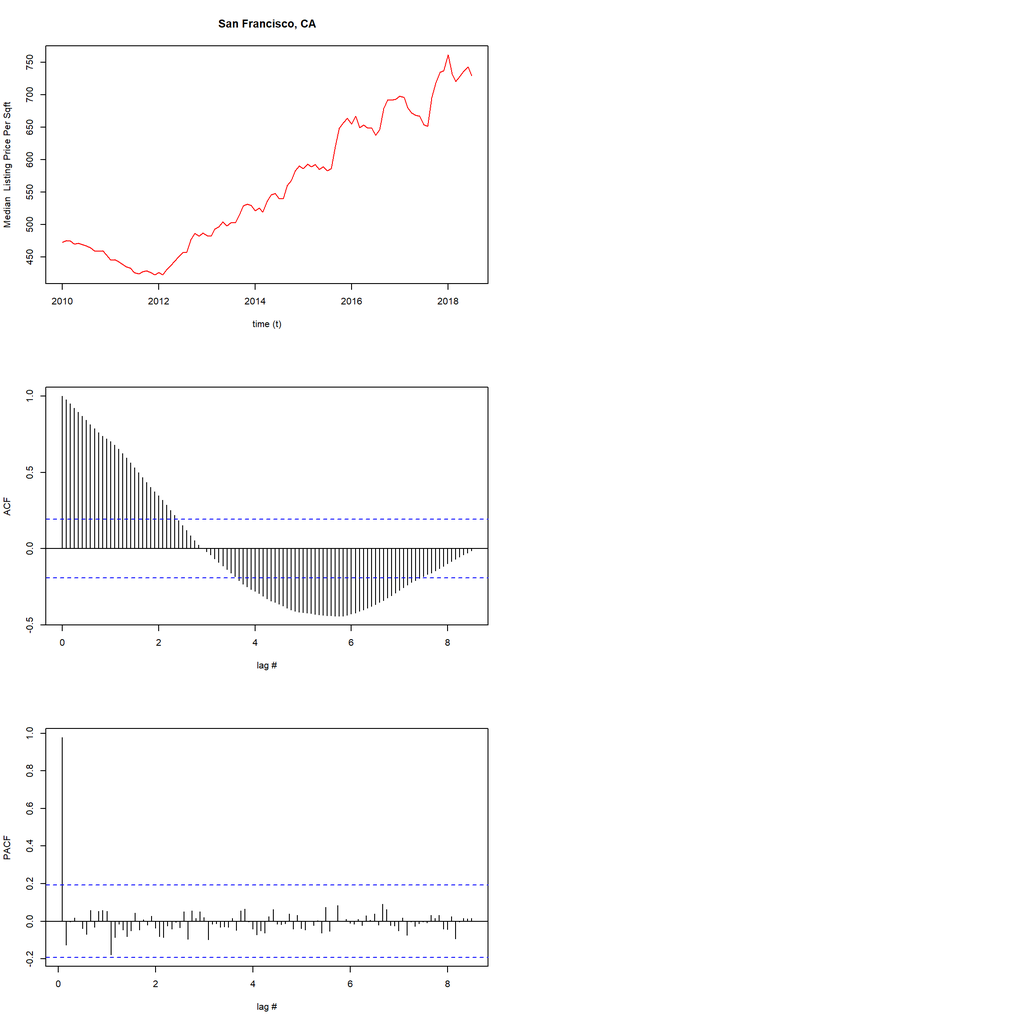

```r
par(mfcol=c(3,2))
# the stationary signal and ACF
for(i in 1:5){
plot(plot_data$Date,ts_1_train[,i],
     type='l',col='red',
     xlab = "time (t)",
     ylab = "Median  Listing Price Per Sqft",
     main = colnames(plot_data)[i])
acf(ts_1_train[,i],lag.max = length(ts_1_train[,i]),
         xlab = "lag #", ylab = 'ACF',main=' ')
pacf(ts_1_train[,i],lag.max = length(ts_1_train[,i]),
         xlab = "lag #", ylab = 'PACF',main=' ')

}
```

##### Qualitatively, We can see and conclude from the ACFs that all the time-series are not stationary (since later lags exceed the confidence interval).

### Stationarity tests

```r
for (i in 1:5){
print(colnames(ts_1_train)[i])
print(adf.test(ts_1_train[,i]))

}
```

```
## [1] "New York, NY"
##
##  Augmented Dickey-Fuller Test
##
## data:  ts_1_train[, i]
## Dickey-Fuller = -3.1369, Lag order = 4, p-value = 0.1053
## alternative hypothesis: stationary
##
## [1] "Los Angeles-Long Beach-Anaheim, CA"
##
##  Augmented Dickey-Fuller Test
##
## data:  ts_1_train[, i]
## Dickey-Fuller = -3.9372, Lag order = 4, p-value = 0.01494
## alternative hypothesis: stationary
##
## [1] "Chicago, IL"
##
##  Augmented Dickey-Fuller Test
##
## data:  ts_1_train[, i]
## Dickey-Fuller = -2.7003, Lag order = 4, p-value = 0.2863
## alternative hypothesis: stationary
##
## [1] "Miami-Fort Lauderdale, FL"
##
##  Augmented Dickey-Fuller Test
##
## data:  ts_1_train[, i]
## Dickey-Fuller = -3.2276, Lag order = 4, p-value = 0.08701
## alternative hypothesis: stationary
##
## [1] "San Francisco, CA"
##
##  Augmented Dickey-Fuller Test
##
## data:  ts_1_train[, i]
## Dickey-Fuller = -3.3277, Lag order = 4, p-value = 0.07033
## alternative hypothesis: stationary
```

##### As can be seen, the time series data of all the 5 cities except Los-Angeles are non-stationary at 0.05 significance level confirming our hypothesis from ACF plots.

### Test for Independence

```r
lag.length = 25

for(i in 1:5){
  print(paste0("Box Test: ", colnames(plot_data)[i]))
  print(Box.test(ts_1_train[,i], lag=lag.length, type="Ljung-Box")) # test stationary signal
}
```

```
## [1] "Box Test: New York, NY"
##
##  Box-Ljung test
##
## data:  ts_1_train[, i]
## X-squared = 1262.6, df = 25, p-value < 2.2e-16
##
## [1] "Box Test: Los Angeles-Long Beach-Anaheim, CA"
##
##  Box-Ljung test
##
## data:  ts_1_train[, i]
## X-squared = 1322.4, df = 25, p-value < 2.2e-16
##
## [1] "Box Test: Chicago, IL"
##
##  Box-Ljung test
##
## data:  ts_1_train[, i]
## X-squared = 917.43, df = 25, p-value < 2.2e-16
##
## [1] "Box Test: Miami-Fort Lauderdale, FL"
##
##  Box-Ljung test
##
## data:  ts_1_train[, i]
## X-squared = 1376.9, df = 25, p-value < 2.2e-16
##
## [1] "Box Test: San Francisco, CA"
##
##  Box-Ljung test
##
## data:  ts_1_train[, i]
## X-squared = 1367.3, df = 25, p-value < 2.2e-16
```

##### Again the above Box Test shows that there is significance evidence for non-zero correlations at given lags(1-25).

### Differencing

```r
#adf test for New York, NY"
adf.test(diff(ts_1[,1]))
```

```
##
##  Augmented Dickey-Fuller Test
##
## data:  diff(ts_1[, 1])
## Dickey-Fuller = -5.9653, Lag order = 4, p-value = 0.01
## alternative hypothesis: stationary
```

```r
#adf test for Los Angeles-Long Beach-Anaheim, CA
adf.test(diff(ts_1[,2]))
```

```
##
##  Augmented Dickey-Fuller Test
##
## data:  diff(ts_1[, 2])
## Dickey-Fuller = -3.7851, Lag order = 4, p-value = 0.02216
## alternative hypothesis: stationary
```

```r
#adf test for Chicago, IL
adf.test(diff(ts_1[,3], differences = 2))
```

```
##
##  Augmented Dickey-Fuller Test
##
## data:  diff(ts_1[, 3], differences = 2)
## Dickey-Fuller = -6.1103, Lag order = 4, p-value = 0.01
## alternative hypothesis: stationary
```

```r
#adf test for Miami-Fort Lauderdale, FL
adf.test(diff(ts_1[,4]))
```

```
##
##  Augmented Dickey-Fuller Test
##
## data:  diff(ts_1[, 4])
## Dickey-Fuller = -5.2693, Lag order = 4, p-value = 0.01
## alternative hypothesis: stationary
```

```r
#adf test for San Francisco, CA
adf.test(diff(ts_1[,5]))
```

```
##
##  Augmented Dickey-Fuller Test
##
## data:  diff(ts_1[, 5])
## Dickey-Fuller = -5.3628, Lag order = 4, p-value = 0.01
## alternative hypothesis: stationary
```

##### Good News, We can fix the stationarity issue by differencing. We can take care of the same by passing differencing arguments in the models

##### We need to take care of the changing variance in each of the time-series by performing BoxCox transformations.

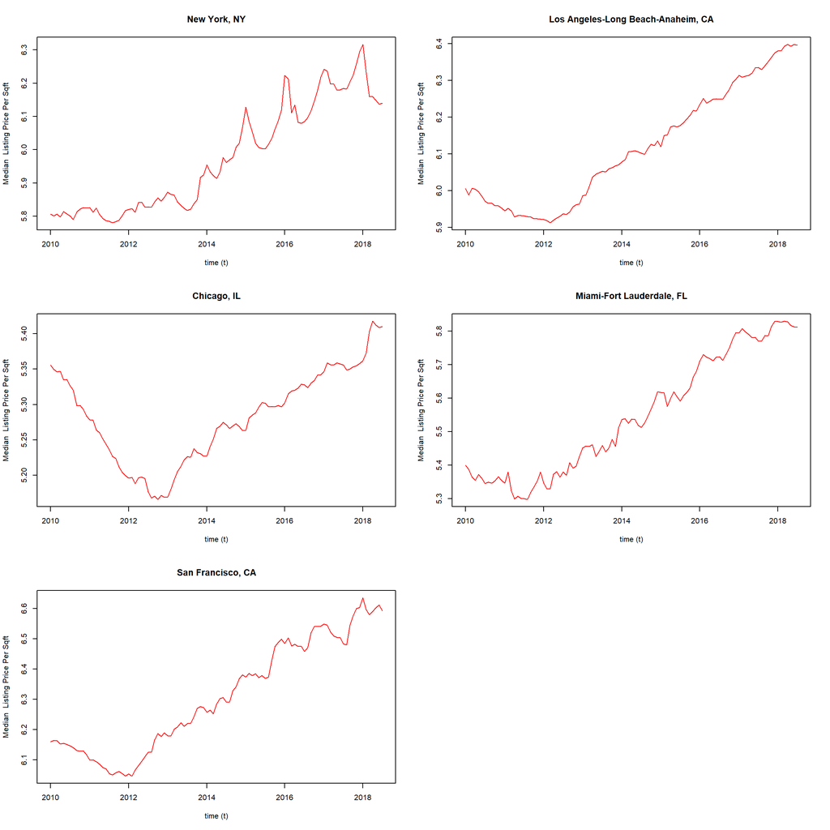

```r
par(mfrow = c(3,2))
ts_2 =ts_1_train
for(i in 1:5){
  ts_2[,i] <- BoxCox(ts_2[,i],0)
  plot(ts_2[,i],
     type='l',col='red',
     xlab = "time (t)",
     ylab = "Median  Listing Price Per Sqft",
     main = colnames(plot_data)[i])
}
```

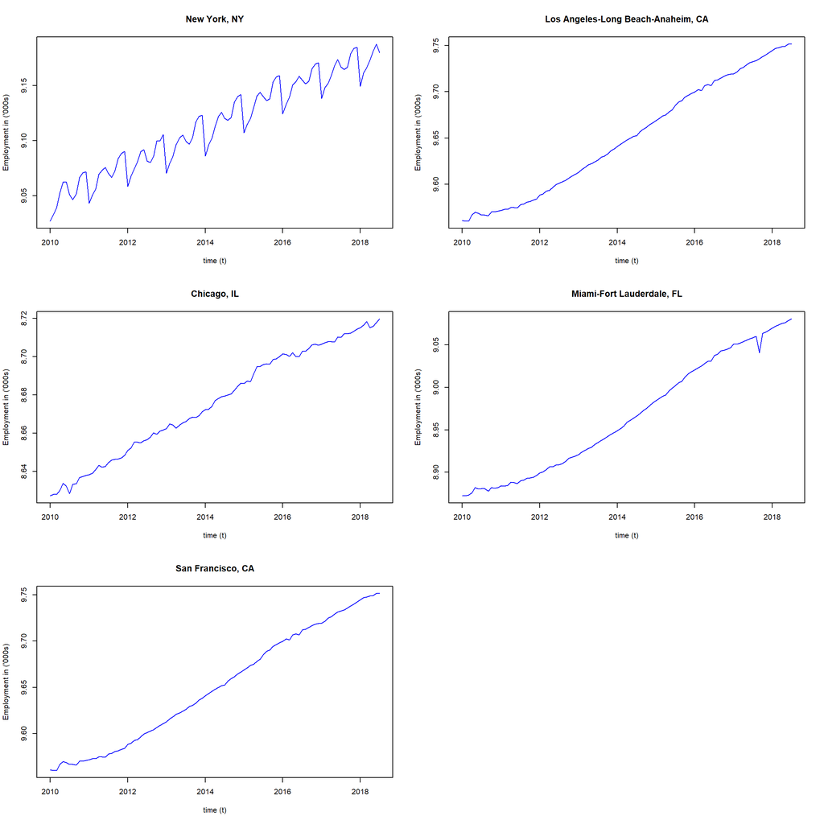

```r
par(mfrow = c(3,2))
ts_emp_2 =ts_emp_train
for(i in 1:5){
  ts_emp_2[,i] <- BoxCox(ts_emp_2[,i],0)
  plot(ts_emp_2[,i],
     type='l',col='blue',
     xlab = "time (t)",
     ylab = "Employment in ('000s)",
     main = colnames(plot_data)[i])
}
```

##### As can be seen, the above time-series have somewhat constant variance across as compared to the untransformed time-series.

#### Plotting correlation between employment and price per sqft

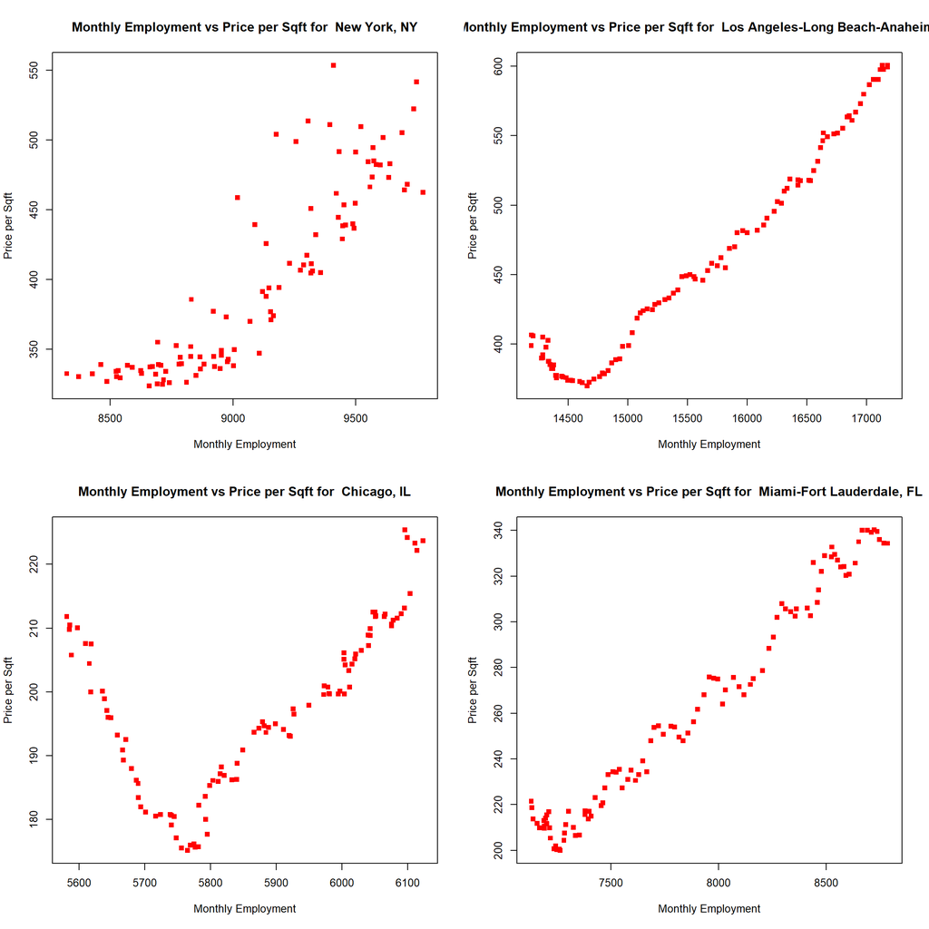

```r
plot_final_data <- as.data.frame(cbind(plot_data, plot_emp_data))
plot_final_data <- plot_final_data[-ncol(plot_final_data)]

plot_final_data <- plot_final_data[,c(6,1,2,3,4,5,7,8,9,10,11)]
colnames(plot_final_data) <- c("Date", "NewYork_Price", "LA_Price", "Chicago_Price", "Miami_Price", "SFO_Price", "NewYork_Empl", "LA_Empl", "Chicago_Empl", "Miami_Empl", "SFO_Empl")

par(mfrow = c(2,2))
for (i in 1 : 5){
  dat = as.data.frame(cbind(plot_final_data[,i + 1], plot_final_data[,i + 6]))
  colnames(dat) <- c("Price", "Employment")

  plot(x = dat[,2], y = dat[,1],
       xlab = 'Monthly Employment', ylab = 'Price per Sqft',
       main = paste('Monthly Employment vs Price per Sqft for ',colnames(ts_1_train)[i]), col= 'red', pch = 15) +
  text(c(2,2),c(37,35),labels=c("Non-case","Case"))
}
```

[output not shown]

[figure not shown]

```r
df <- as.data.frame(matrix(NA, nrow = 1, ncol = 5))
rownames(df) <- "Correlation b/w Housing Price and Employment"

for(i in 1:5){
  df[1,i] <- cor(plot_final_data[,i + 1], plot_final_data[,i + 6])
  colnames(df)[i] <- colnames(ts_emp)[i]

}

df
```

#### Testing using adf test, and acf by using differencing on log of price and employment.

```
## [1] "New York, NY"
##
##  Augmented Dickey-Fuller Test
##
## data:  diff(ts_log[, i], differences = 2)
## Dickey-Fuller = -6.5077, Lag order = 4, p-value = 0.01
## alternative hypothesis: stationary
```

```
## [1] "Los Angeles-Long Beach-Anaheim, CA"
##
##  Augmented Dickey-Fuller Test
##
## data:  diff(ts_log[, i], differences = 2)
## Dickey-Fuller = -8.7428, Lag order = 4, p-value = 0.01
## alternative hypothesis: stationary
```

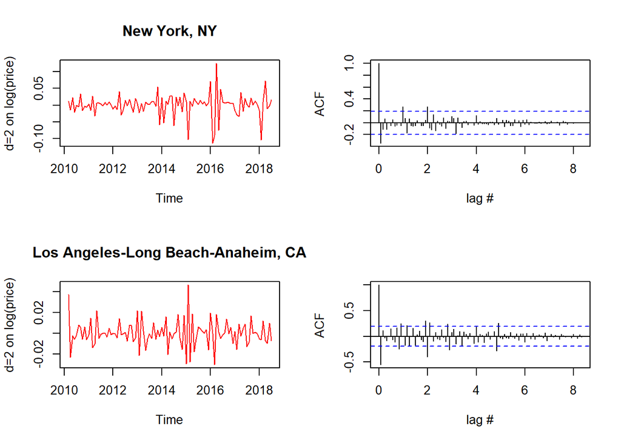

```
## [1] "Chicago, IL"
##
##  Augmented Dickey-Fuller Test
##
## data:  diff(ts_log[, i], differences = 2)
## Dickey-Fuller = -5.2809, Lag order = 4, p-value = 0.01
## alternative hypothesis: stationary
```

```
## [1] "Miami-Fort Lauderdale, FL"
##
##  Augmented Dickey-Fuller Test
##
## data:  diff(ts_log[, i], differences = 2)
## Dickey-Fuller = -6.4757, Lag order = 4, p-value = 0.01
## alternative hypothesis: stationary
```

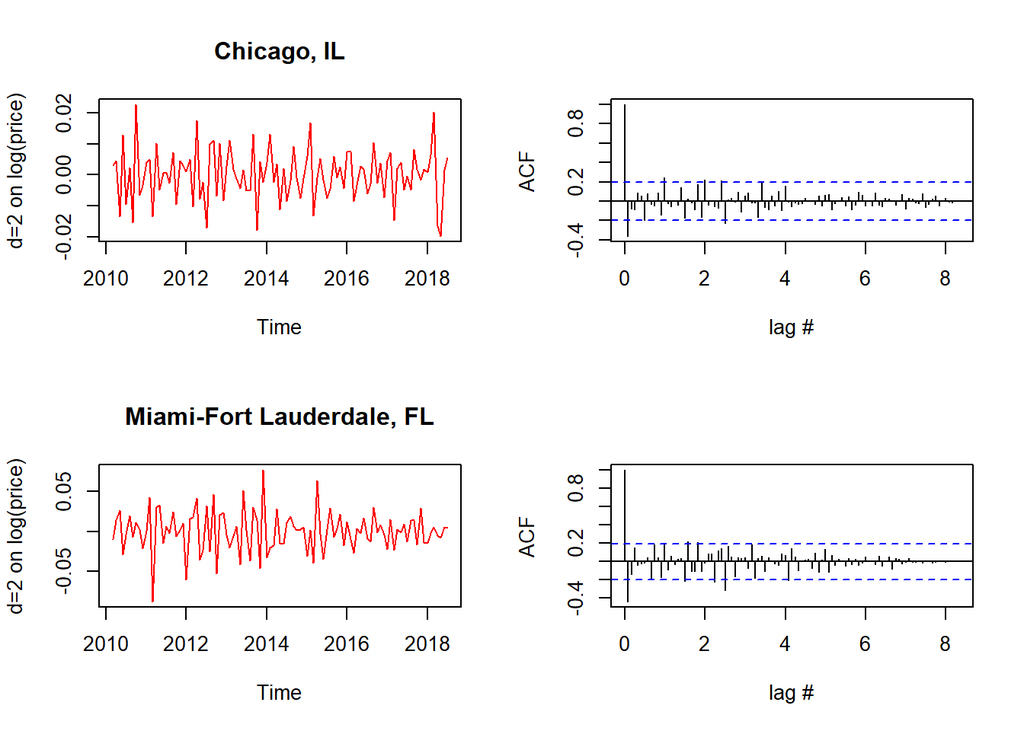

```
## [1] "San Francisco, CA"
##
##  Augmented Dickey-Fuller Test
##
## data:  diff(ts_log[, i], differences = 2)
## Dickey-Fuller = -6.2694, Lag order = 4, p-value = 0.01
## alternative hypothesis: stationary
```

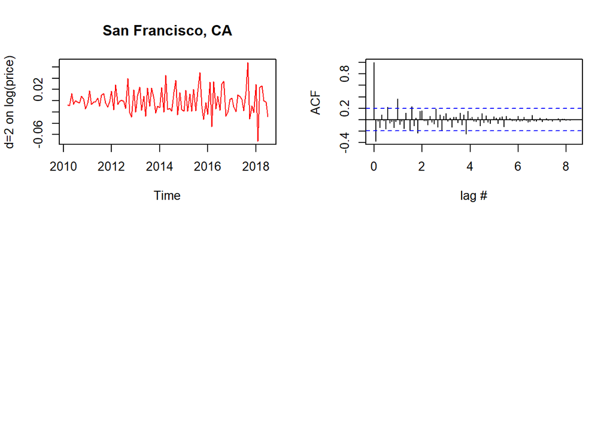

```r
ts_log = log(ts_1_train)
#head(ts_log)



par(mfrow = c(2,2))
for(i in 1:5){
   print(colnames(ts_log)[i])
  print(adf.test(diff(ts_log[,i],differences= 2)))
  plot(diff(ts_log[,i],differences = 2),main = colnames(ts_log)[i], ylab = 'd=2 on log(price)', type='l',col='red')
  acf(diff(ts_log[,i],differences = 2),lag.max = length(ts_1_train[,i]),
         xlab = "lag #", ylab = 'ACF',main=' ')

}
```

#### Differencing logs of employment data

```
## [1] "NewYork"
##
##  Augmented Dickey-Fuller Test
##
## data:  diff(ts_emp_train_log[, i], differences = 2)
## Dickey-Fuller = -12.823, Lag order = 4, p-value = 0.01
## alternative hypothesis: stationary
```

```
## [1] "LosAngeles"
##
##  Augmented Dickey-Fuller Test
##
## data:  diff(ts_emp_train_log[, i], differences = 2)
## Dickey-Fuller = -10.142, Lag order = 4, p-value = 0.01
## alternative hypothesis: stationary
```

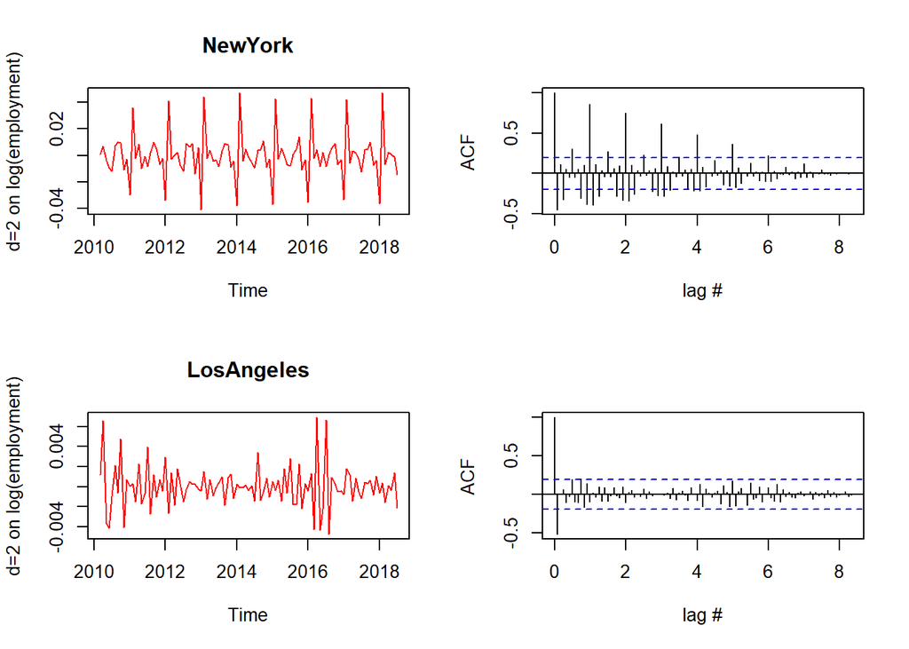

```
## [1] "Chicago"
##
##  Augmented Dickey-Fuller Test
##
## data:  diff(ts_emp_train_log[, i], differences = 2)
## Dickey-Fuller = -11.004, Lag order = 4, p-value = 0.01
## alternative hypothesis: stationary
```

```
## [1] "Miami"
##
##  Augmented Dickey-Fuller Test
##
## data:  diff(ts_emp_train_log[, i], differences = 2)
## Dickey-Fuller = -9.0897, Lag order = 4, p-value = 0.01
## alternative hypothesis: stationary
```

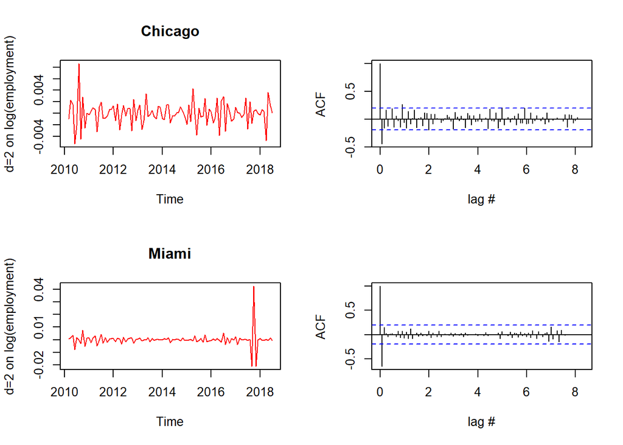

```
## [1] "SFO"
##
##  Augmented Dickey-Fuller Test
##
## data:  diff(ts_emp_train_log[, i], differences = 2)
## Dickey-Fuller = -10.142, Lag order = 4, p-value = 0.01
## alternative hypothesis: stationary
```

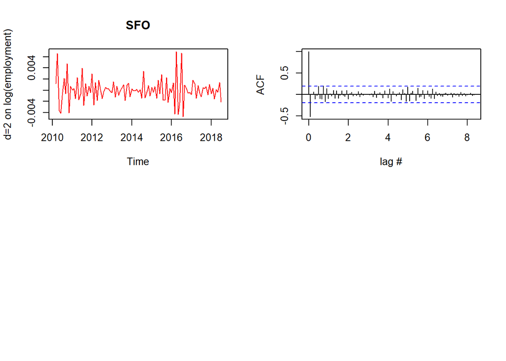

```r
ts_emp_train_log = log(ts_emp_train)
#head(ts_emp_train_log)
par(mfrow = c(2,2))
for(i in 1:5){
   print(colnames(ts_emp_train_log)[i])
  print(adf.test(diff(ts_emp_train_log[,i],differences= 2)))
  plot(diff(ts_emp_train_log[,i],differences = 2),main = colnames(ts_emp_train_log)[i], ylab = 'd=2 on log(employment)', type='l',col='red')
  acf(diff(ts_emp_train_log[,i],differences = 2),lag.max = length(ts_1_train[,i]),
         xlab = "lag #", ylab = 'ACF',main=' ')

}
```

#### Applying ts linear model on each of the cities with y = log(price) and x = log(employment)

```r
mod.lm.ny = tslm(formula = ts_log[,1] ~ ts_emp_train_log[,1] )
mod.lm.la = tslm(formula = ts_log[,2] ~ ts_emp_train_log[,2] )
mod.lm.ch = tslm(formula = ts_log[,3] ~ ts_emp_train_log[,3] )
mod.lm.mi = tslm(formula = ts_log[,4] ~ ts_emp_train_log[,4] )
mod.lm.sf = tslm(formula = ts_log[,5] ~ ts_emp_train_log[,5] )
```

#### Plotting regression line vs observations to see goodness of fit

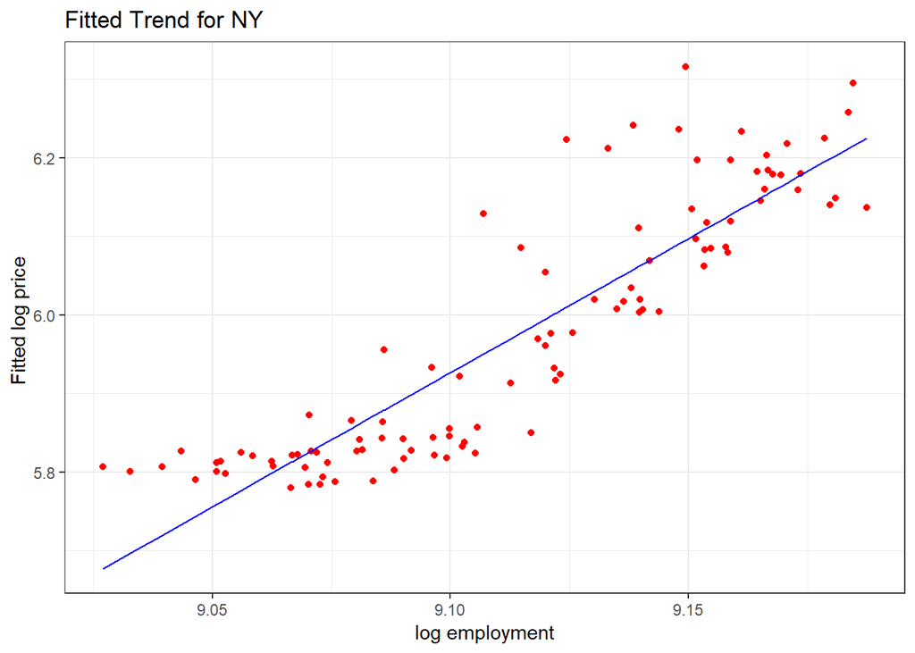

```r
par(mfrow= c(1,1))
ggplot()+
  geom_point(aes(x = ts_emp_train_log[,1], y = ts_log[,1]),color ='red')+
  geom_line(aes(x = ts_emp_train_log[,1], y = mod.lm.ny$fitted.values), color = 'blue')+
  xlab('log employment')+
  ylab('Fitted log price ')+
  ggtitle('Fitted Trend for NY')+
  theme_bw()
```

#### Los Angeles

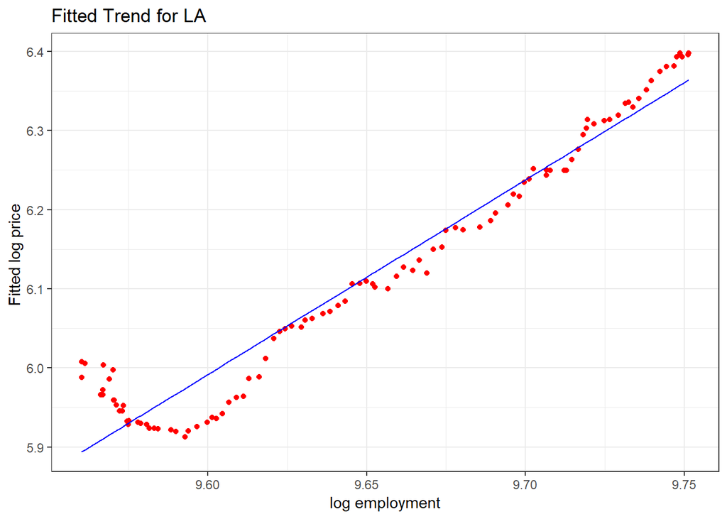

```r
ggplot()+
  geom_point(aes(x = ts_emp_train_log[,2], y = ts_log[,2]),color ='red')+
  geom_line(aes(x = ts_emp_train_log[,2], y = mod.lm.la$fitted.values), color = 'blue')+
  xlab('log employment')+
  ylab('Fitted log price ')+
  ggtitle('Fitted Trend for LA')+
  theme_bw()
```

#### Chicago

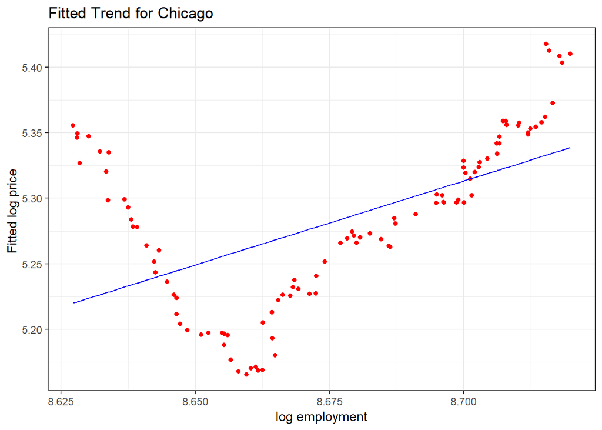

```r
ggplot()+
  geom_point(aes(x = ts_emp_train_log[,3], y = ts_log[,3]),color ='red')+
  geom_line(aes(x = ts_emp_train_log[,3], y = mod.lm.ch$fitted.values), color = 'blue')+
  xlab('log employment')+
  ylab('Fitted log price ')+
  ggtitle('Fitted Trend for Chicago')+
  theme_bw()
```

#### Miami

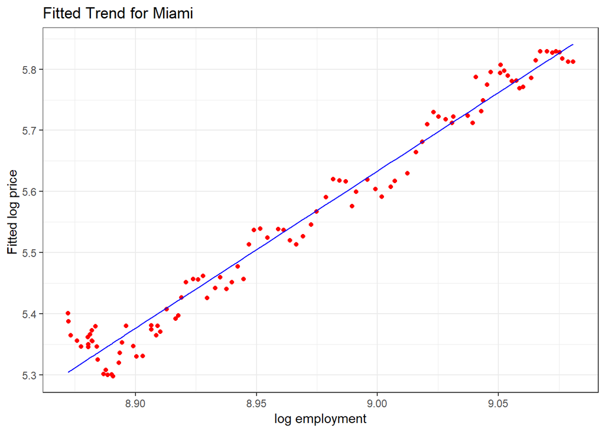

```r
ggplot()+
  geom_point(aes(x = ts_emp_train_log[,4], y = ts_log[,4]),color ='red')+
  geom_line(aes(x = ts_emp_train_log[,4], y = mod.lm.mi$fitted.values), color = 'blue')+
  xlab('log employment')+
  ylab('Fitted log price ')+
  ggtitle('Fitted Trend for Miami')+
  theme_bw()
```

#### SFO

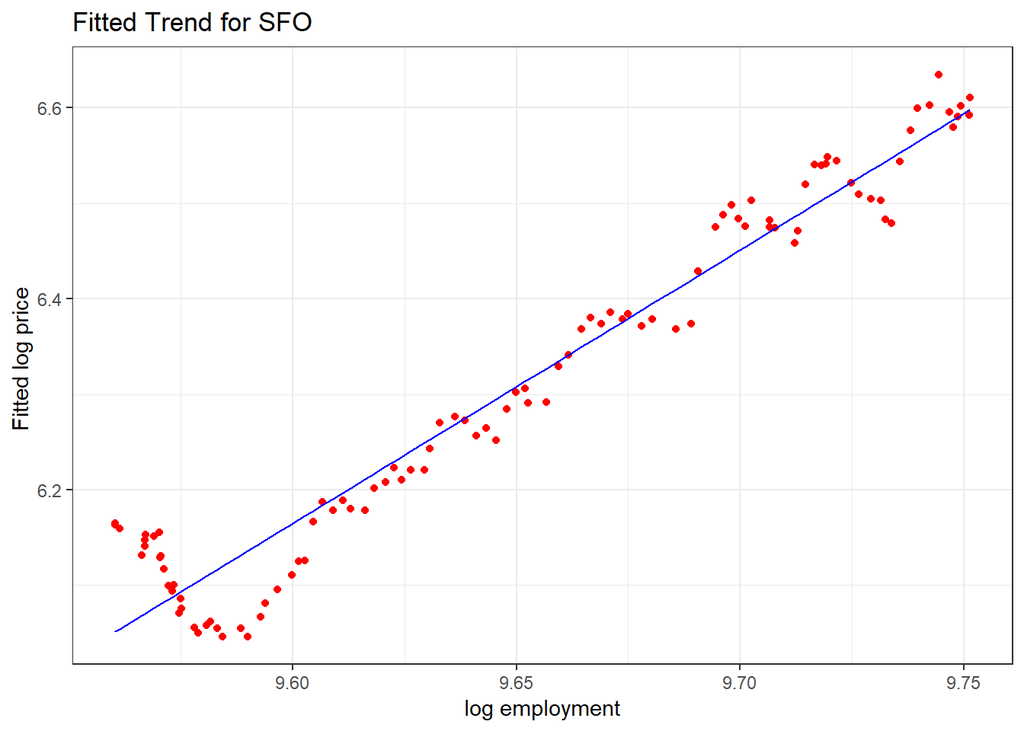

```r
ggplot()+
  geom_point(aes(x = ts_emp_train_log[,5], y = ts_log[,5]),color ='red')+
  geom_line(aes(x = ts_emp_train_log[,5], y = mod.lm.sf$fitted.values), color = 'blue')+
  xlab('log employment')+
  ylab('Fitted log price ')+
  ggtitle('Fitted Trend for SFO')+
  theme_bw()
```

#### Check residuals & summary for lm model for NY

```r
summary(mod.lm.ny)
```

```
##
## Call:
## tslm(formula = ts_log[, 1] ~ ts_emp_train_log[, 1])
##
## Residuals:
##      Min       1Q   Median       3Q      Max
## -0.13441 -0.04994 -0.01124  0.04389  0.22089
##
## Coefficients:
##                       Estimate Std. Error t value Pr(>|t|)
## (Intercept)           -25.1337     1.5715  -15.99   <2e-16 ***
## ts_emp_train_log[, 1]   3.4132     0.1724   19.80   <2e-16 ***
## ---
## Signif. codes:  0 '***' 0.001 '**' 0.01 '*' 0.05 '.' 0.1 ' ' 1
##
## Residual standard error: 0.07317 on 101 degrees of freedom
## Multiple R-squared:  0.7951, Adjusted R-squared:  0.793
## F-statistic: 391.9 on 1 and 101 DF,  p-value: < 2.2e-16
```

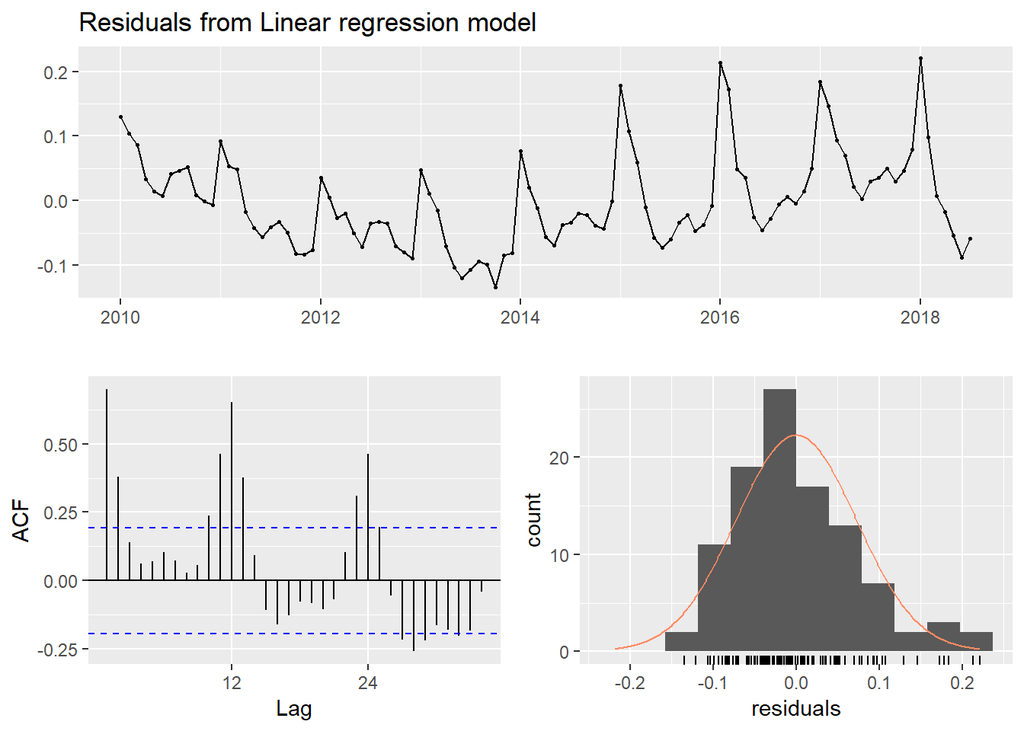

```
##
##  Breusch-Godfrey test for serial correlation of order up to 21
##
## data:  Residuals from Linear regression model
## LM test = 88.365, df = 21, p-value = 3.085e-10
```

```r
checkresiduals(mod.lm.ny)
```

#### Check residuals & summary for lm model for LA

```r
summary(mod.lm.la)
```

```
##
## Call:
## tslm(formula = ts_log[, 2] ~ ts_emp_train_log[, 2])
##
## Residuals:
##       Min        1Q    Median        3Q       Max
## -0.062485 -0.019715 -0.006154  0.019643  0.113348
##
## Coefficients:
##                        Estimate Std. Error t value Pr(>|t|)
## (Intercept)           -17.61581    0.56853  -30.98   <2e-16 ***
## ts_emp_train_log[, 2]   2.45911    0.05891   41.74   <2e-16 ***
## ---
## Signif. codes:  0 '***' 0.001 '**' 0.01 '*' 0.05 '.' 0.1 ' ' 1
##
## Residual standard error: 0.03689 on 101 degrees of freedom
## Multiple R-squared:  0.9452, Adjusted R-squared:  0.9447
## F-statistic:  1742 on 1 and 101 DF,  p-value: < 2.2e-16
```

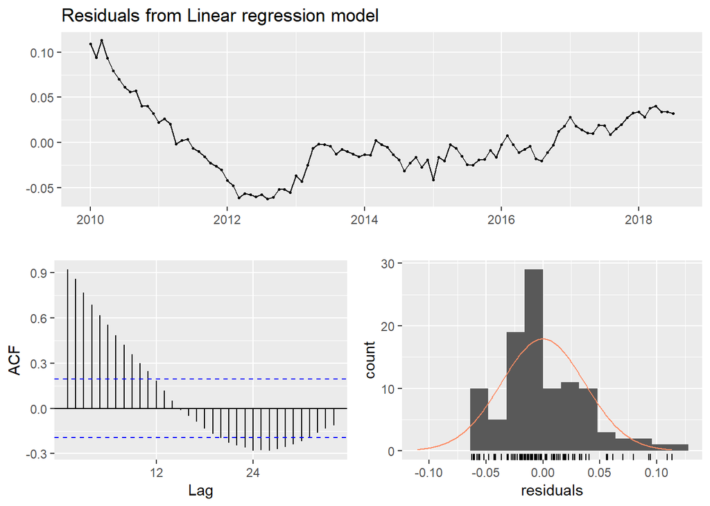

```
##
##  Breusch-Godfrey test for serial correlation of order up to 21
##
## data:  Residuals from Linear regression model
## LM test = 89.816, df = 21, p-value = 1.736e-10
```

```r
checkresiduals(mod.lm.la)
```

#### Check residuals & summary for lm model for Chicago

```r
summary(mod.lm.ch)
```

```
##
## Call:
## tslm(formula = ts_log[, 3] ~ ts_emp_train_log[, 3])
##
## Residuals:
##      Min       1Q   Median       3Q      Max
## -0.09639 -0.03899 -0.01051  0.02925  0.13568
##
## Coefficients:
##                       Estimate Std. Error t value Pr(>|t|)
## (Intercept)             -5.835      1.675  -3.484 0.000732 ***
## ts_emp_train_log[, 3]    1.281      0.193   6.638 1.62e-09 ***
## ---
## Signif. codes:  0 '***' 0.001 '**' 0.01 '*' 0.05 '.' 0.1 ' ' 1
##
## Residual standard error: 0.05475 on 101 degrees of freedom
## Multiple R-squared:  0.3037, Adjusted R-squared:  0.2968
## F-statistic: 44.06 on 1 and 101 DF,  p-value: 1.615e-09
```

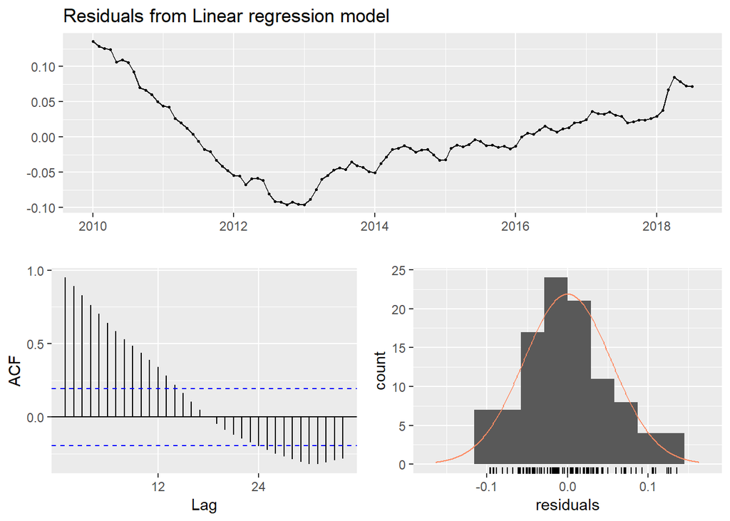

```
##
##  Breusch-Godfrey test for serial correlation of order up to 21
##
## data:  Residuals from Linear regression model
## LM test = 95.158, df = 21, p-value = 2.051e-11
```

```r
checkresiduals(mod.lm.ch)
```

#### Check residuals & summary for lm model for Miami

```r
summary(mod.lm.mi)
```

```
##
## Call:
## tslm(formula = ts_log[, 4] ~ ts_emp_train_log[, 4])
##
## Residuals:
##       Min        1Q    Median        3Q       Max
## -0.054668 -0.024325 -0.000265  0.022265  0.096070
##
## Coefficients:
##                        Estimate Std. Error t value Pr(>|t|)
## (Intercept)           -17.52735    0.38995  -44.95   <2e-16 ***
## ts_emp_train_log[, 4]   2.57342    0.04349   59.17   <2e-16 ***
## ---
## Signif. codes:  0 '***' 0.001 '**' 0.01 '*' 0.05 '.' 0.1 ' ' 1
##
## Residual standard error: 0.02988 on 101 degrees of freedom
## Multiple R-squared:  0.972,  Adjusted R-squared:  0.9717
## F-statistic:  3502 on 1 and 101 DF,  p-value: < 2.2e-16
```

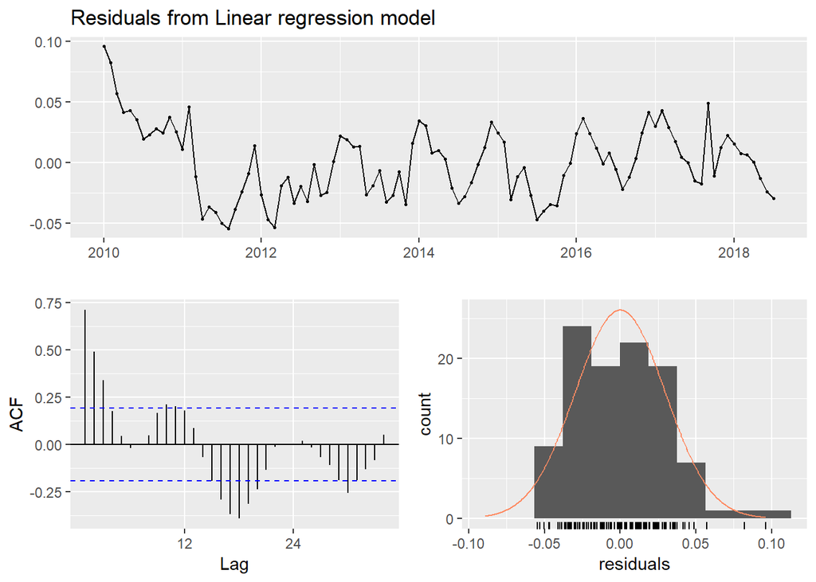

```
##
##  Breusch-Godfrey test for serial correlation of order up to 21
##
## data:  Residuals from Linear regression model
## LM test = 61.317, df = 21, p-value = 8.053e-06
```

```r
checkresiduals(mod.lm.mi)
```

#### Check residuals & summary for lm model for SFO

```r
summary(mod.lm.sf)
```

```
##
## Call:
## tslm(formula = ts_log[, 5] ~ ts_emp_train_log[, 5])
##
## Residuals:
##       Min        1Q    Median        3Q       Max
## -0.089411 -0.024888 -0.005395  0.025999  0.113727
##
## Coefficients:
##                        Estimate Std. Error t value Pr(>|t|)
## (Intercept)           -21.30440    0.65638  -32.46   <2e-16 ***
## ts_emp_train_log[, 5]   2.86138    0.06801   42.07   <2e-16 ***
## ---
## Signif. codes:  0 '***' 0.001 '**' 0.01 '*' 0.05 '.' 0.1 ' ' 1
##
## Residual standard error: 0.04259 on 101 degrees of freedom
## Multiple R-squared:  0.946,  Adjusted R-squared:  0.9455
## F-statistic:  1770 on 1 and 101 DF,  p-value: < 2.2e-16
```

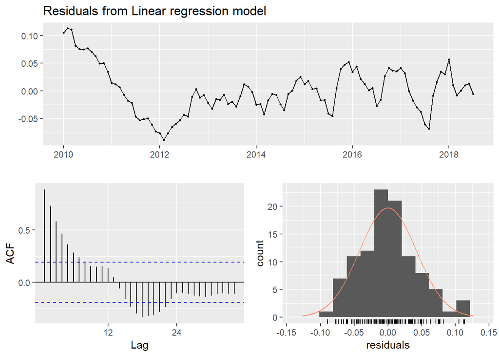

```
##
##  Breusch-Godfrey test for serial correlation of order up to 21
##
## data:  Residuals from Linear regression model
## LM test = 86.534, df = 21, p-value = 6.351e-10
```

```r
checkresiduals(mod.lm.sf)
```